# Pipeline for the Rasplus *et al* paper on the RADseq phylogenomics of *Ficus* species.

> Contents:
> - 1 Preliminary notes
> - 2 Goal and warnings
> - 3 External resources
> - 4 Reference genomes
> - 5 Pipeline
> - 5.1 Part One: Assembly of reads1 and reads2 and confirmation of sequence homology
> - 5.2 Part Two: Retrieval of RAD loci in outgroup reference genomes

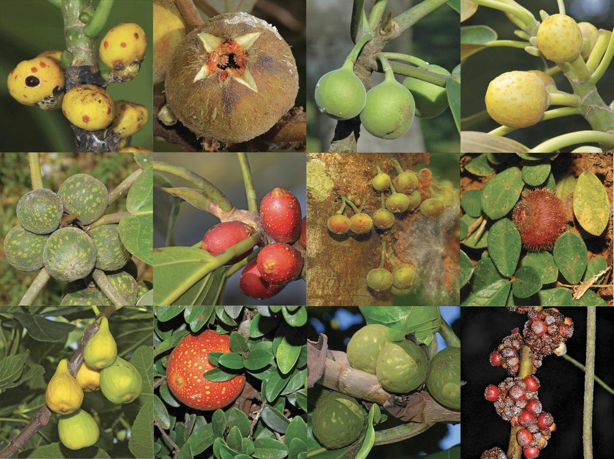

From left down to right up. Figs of *F. carica* (*Ficus*, France), *F. aurantiacea* (*Synoecia*, Borneo), *F. lyrata* (*Galoglychia*, Ivory Coast), *F. minahassae* (*Sycomorus*, Philippines), *F. torresiana* (*Pharmacosycea*, Costa Rica), *F. forstenii* (*Conosycea*, Sulawesi), *F. elmeri* (*Sycidium*, Philippines), *F. vaccinioides* (*Podosyceae*, Taiwan), *F. aurea* (*Americanae*, USA), *F. padana* (*Eriosycea*, Indonesia), *F. callosa* (*Oreosycea*, China), *F. macrophylla* (*Malvanthera*, Australia). All photos ⒸJ.-Y. Rasplus & A. Cruaud.

# Preliminary notes

This document details the pipeline used in the Rasplus et al paper for the assembly of forward (R1 or reads1) and reverse (R2 or reads2) reads and to retrieve RAD loci from genome of outgroup species.  
The pipeline has been designed by J.-Y. Rasplus and A. Cruaud and written by AC.  
Most parts of the pipeline were written for a Linux server (Ubuntu 15.10; Dell PowerEdge T630 server with two 10-core Intel(R) Xeon(R) CPUs E5-2687W v3 @ 3.10GHz) and some were written for a [SLURM cluster controller](http://bioinfo.genotoul.fr/).  
Were are not professional bioinformaticians yet we try to do our best! So, the code will not appear clean to purists (apologize for that) and there are certainly other ways to reach the same goal !

**Source code for scripts mentioned in the pipeline are in https://github.com/acruaud/radseq_ficus_2020**. The scripts were written by M. Gautier and modified by AC.

# Goal and warnings

**Note:** This pipeline is written to work with the results provided by the wrapper [RADIS](http://www1.montpellier.inra.fr/CBGP/software/RADIS/) that relies on [Stacks](http://catchenlab.life.illinois.edu/stacks/) for the building of RAD loci from forward reads, but it can be used directly on Stacks results, provided that:

the correct paths to files /scripts are given,

R1 and R2 are named with the same string of characters and the suffix _1 or _2 (e.g. R1 name = @8_1101_1942_1994_1 /R2 name = @8_1101_1942_1994_2),

a list of cstacks locus ids is provided which is simply a list of numbers (when you use RADIS the list is in a stacks_M$Mn$nS$SL$L.sel file).

```bash
#example of a list of cstacks locus ids
head -n 10 stacks_M2n20S56L100.sel
3
9
17
24
27
33
```

**Goals:** Starting from a list of cstacks locus ids (reads1 only loci), assembly of reads1 and reads2 to increase length of loci to:

1. enable a more accurate calculation of locus properties and a better selection of loci to decrease potential bias in phylogenetic inference,
2. retrieve RAD loci in outgroups for which restriction sites have been lost because of divergence.

**Attention:**

You need to adapt path to your own file tree structure and change filenames if needed.

You need to edit the retrieve_read2ids.awk script to change path to the sel_fq_2.awk script.

You may need to make script executable before use: chmod +x scriptname

Our sample codes are formatted as follows: AlphanumericCode_NumericCode (e.g JRAS01331_0001). Some parts of the pipelines (statistics) may fail if you do not use the same format (StringOfCharacters_StringOfCharacters), adapt cmd to your case and check that you obtain the desired output before moving to the next step.

# External resources

Some parts of the pipeline require the following softwares /scripts (or equivalents):

catfasta2phyml: for the concatenation of all loci into a supermatrix.

[Fasta2Phylip.pl](http://indra.mullins.microbiol.washington.edu/perlscript/docs/Sequence.html): to convert fasta to phylip.

[Geneious](https://www.geneious.com/): for visualization of sequences (version used = 11.1.4).

[MAFFT](https://mafft.cbrc.jp/alignment/software/): for locus by locus alignment (version used = 7.313).

samclip: to remove sequences with hard /soft clipped unaligned ends from sam files.

[samtools](http://www.htslib.org/): to work with .sam files (version used = 1.9 with htslib 1.9).

Sequence-manipulation: to build consensus sequence from non overlaping fasta.

[trimal](https://vicfero.github.io/trimal/index.html): to remove alignment position with 100% gaps (version used = v1.4.rev22 build[2015-05-21]).

Trinity: for the assembly of forward and reverse reads (version used = 2.3.2).

# Reference genomes

The genome of *Ficus carica*, assembly GCA_002002945.1, was used for the alignment of contigs of forward and reverse reads.

The genomes of *Morus notabilis* [GCA_000414095.2](https://www.ncbi.nlm.nih.gov/assembly/GCF_000414095.1/) and *Artocarpus camansi* [GCA_002024485.1](https://www.ncbi.nlm.nih.gov/assembly/GCA_002024485.1/), the only two other Moraceae species for which a genome was available when we conducted the study were screened for RAD loci.

# **Part One: Assembly of reads1 and reads2 and confirmation of sequence homology**

**Step 1: from a list of cstacks locus ids retrieve forward and corresponding reverse reads**

Unzip fq_2.gz files for the samples included in your analysis.  
If you used RADIS the files are stored in the 04_PUR subdirectory-ies of the outdir_datacleaning directory(ies).

```bash
for i in *fq_2.gz
do
gunzip $i
done
```

Create a datadir for your analysis and cd to datadir.

```bash
cd /home/cruaud/rad_ficus/outdir_dataanalysis_m15M2n20S56L100/M2/NO_PBLOCI-3/n20_03_SEL   #here we create our datadir in the output directory of RADIS where the R1 loci were built
mkdir assembly_reads1reads2   #and my datadir will be named assembly_reads1reads2
cd assembly_reads1reads2
```

Create symbolic links (to keep space) or copy $sample_code.fq_1 (=fastq files that contain the reads1 for each sample included in your analysis) and $sample_code.fq_2 (=fastq files that contain the reads2 for each sample included in your analysis) files to datadir.  
The samples we studied come from 2 libraries, so we execute the command twice with 2 different paths.

reads1

```bash
ls /home/cruaud/articles/rad_ficus/lib1/outdir_datacleaning/PBC/04_PUR/*.fq_1 |awk '{print "ln -s "$1}' | bash
ls /home/cruaud/articles/rad_ficus/lib2_reseq/outdir_datacleaning/PBC/04_PUR/*.fq_1 |awk '{print "ln -s "$1}' | bash
```

reads2

```bash
ls /home/cruaud/articles/rad_ficus/lib1/outdir_datacleaning/PBC/04_PUR/*.fq_2 |awk '{print "ln -s "$1}' | bash
ls /home/cruaud/articles/rad_ficus/lib2_reseq/outdir_datacleaning/PBC/04_PUR/*.fq_2 |awk '{print "ln -s "$1}' | bash
```

Create a file that lists all *.tags.tsv files created by ustacks + their path.

```bash
ls ../../../01_TAGS/*tags.tsv > batch_1.files
```

Execute the retrieve_ustacks_ids.awk script to get, for each sample, the list of ustacks loci merged in the different cstacks loci.  
Provide a list of cstacks locus ids (here a .sel file generated by RADIS) and the corresponding cstacks catalog.tags.tsv as input.

```
#run the script
gawk -f /home/cruaud/programs/rad/retrieve_ustacks_ids.awk batch_1.files ../stacks_M2n20S56L100.sel ../../../02_CATALOG/batch_20.catalog.tags.tsv

#Output = retrieve_ustacks_ids.out
#column1 = cstacks locus id
#column2 = path to $sample_code.tags.tsv file
#column3 = locus id in sample.tags.tsv file
```

Execute the retrieve_read2ids.awk script to get, for each sample, the list of reads2 ids to retrieve and a script file to retrieve them.  
**Attention: Do not forget to edit the retrieve_read2ids.awk script to change path to the sel_fq_2.awk script before running.**  
Provide a list of cstacks locus ids (here a .sel file generated by RADIS), the retrieve_ustacks_ids.out created in the previous step and the path to ustacks *tags.tsv files as input.

```bash
/home/cruaud/programs/rad/retrieve_read2ids.awk ../stacks_M2n20S56L100.sel retrieve_ustacks_ids.out ../../../01_TAGS/*tags.tsv

#Output 1 = $sample_code.read2.lst    #as many files as the number of samples are created
#column1 = read2 ids
#column2 = cstacks locus id

#Output 2 = retrieve_read2.run #that contains a list of commands to retrieve reads2 from $sample_code.fq_2 files with the sel_fq_2.awk script
```

Make executable and execute the retrieve_read2.run file created at the previous step to retrieve reads2 in fq_2 files.

```bash
chmod +x retrieve_read2.run
./retrieve_read2.run

#Output = $sample_code.fq_2.sel    #as many files as the number of samples are created
#the output is a fastq file with 3 extra columns added to each line
#column1 = cstacks_locus_id
#column2 = $sample_code.fq_2
#column3 = line_number_in_$sample_code.fq_2    #to facilitate sorting
```

Retrieve corresponding reads1:

1. Convert $sample_code.read2.lst files into $sample_code.read1.lst files

```bash
for i in *.read2.lst
do
sed s/"_2 "/"_1 "/g $i > $i".read1.lst"
done
```

2. Rename output files (clean extension).

```bash
rename s/"\.read2\.lst"/""/g *.read1.lst
```

3. Convert retrieve_read2.run script into retrieve_read1.run.

```bash
sed s/"read2"/"read1"/g retrieve_read2.run |sed s/"fq_2"/"fq_1"/g > retrieve_read1.run
```

4. Make executable and execute retrieve_read1.run.

```bash
chmod +x retrieve_read1.run
./retrieve_read1.run
```

Sort the resulting .sel files for reads1 and reads2.

```bash
for i in *.sel
do
sort -k2,2 -k3,3 -k4n,4n $i > $i.sort
done

#Output = $sample_code.fq_1.sel.sort and $sample_code.fq_2.sel.sort
#as many files as the number of samples are created and reads are now sorted by cstacks locus ids (column2 of the files)
```

Use the parse_fq_sel.pl script to split $sample_code.fq_$i.sel.sort files into $cstackslocusid_$sample_code.fq_1 and .fq_2 files and store all resulting files in a subdirectory.

```bash
for i in *sel.sort
do
/home/cruaud/programs/rad/parse_fq_sel.pl --inputfile $i --outputdir assembly    #here the output directory name will be "assembly" but you can change it if you like
done

#Output = .fastq files which are stored in the assembly directory
#output filenames = cstackslocusid_$sample_code.fq_1 and cstackslocusid_$sample_code.fq_2
```

Cleaning to save space.  
You can remove all files with the exception of the “assembly”" directory, or you may keep the symbolic links and batch_1.files if you need to re-run analyses.

```bash
rm *.sel *.sort *.lst retrieve_ustacks_ids.out retrieve_read*.run
```

**End of step 1: For all samples included in your analysis, and all selected cstacks loci, you should now have fastq files for forward and reverse reads in the “assembly” directory**

**Step 2: assembly of forward and reverse reads**

We use [Trinity](https://www.ncbi.nlm.nih.gov/pmc/articles/PMC3875132/) but you may use your favorite assembler

Replace the last occurrence of _1 by /1 in *fq_1 files for trinity assembly.

```bash
for i in *.fq_1
do
sed -i 's/\(.*\)_1/\1\/1/' $i
done
```

Replace the last occurrence of _2 by /2 in *fq_2 files for trinity assembly.

```bash
for i in *.fq_2
do
sed -i 's/\(.*\)_2/\1\/2/' $i
done
```

```bash
ls *.fq_1 |sed s/"\.fq_1"/""/g > mysamples.txt
```

Prepare cmd file.

```bash
awk '{print "#!\/bin\/bash\n#SBATCH -J trinity\n#SBATCH -p workq\n#SBATCH --cpus-per-task=4\n#SBATCH -t 02:00:00\n\nmodule load bioinfo\/trinityrnaseq-v2.3.2\nmodule load bioinfo\/bowtie2-2.2.9\n\nTrinity --seqType fq --left "$1".fq_1 --right "$1".fq_2 --output trinity_"$1" --full_cleanup --CPU 4 --max_memory 2G --min_contig_length 100"}' mysamples.txt > tmp_cmd

#nota: --min_contig_length should be lower or equal to the length of your R1 RAD loci, if not, contigs of R1 will not be retained by trinity
```

Split the cmd file into as many scripts as the number of samples (trinity_xx.sh scripts will be created).

```bash
awk '/#!/{filename="trinity_"NR".sh"}; {print >filename}' tmp_cmd
```

Run all scripts (as many scripts as the number of samples will be submitted).

```bash
for i in trinity_*.sh
do
sbatch $i
done

#output = trinity_$samplecode.Trinity.fas
```

When all jobs are over, check that everything ran properly

```bash
ls *.Trinity.fasta |wc -l    #should be equal to the number of samples you wanted to assemble reads for
```

Note: You should have at least one contig for each sample (at least a contig of reads1). If there are some samples for which no assembly is produced, we suggest to perform assembly in [Geneious](https://www.geneious.com/).

Once the assembly is finished, we upload all trinity contigs to our personal Linux server in a new assembly/trinity directory and go back to our server.  
So, cd to datadir.

```bash
cd assembly/trinity
```

Compute some statistics.

```bash
#number of contigs per sample
grep -c ">" trinity_* |sed s/"trinity_"/""/g |sed s/"_fq\.fa\.Trinity\.fasta:"/";"/g > nbcontigs_persample.txt
#average contig length
for i in trinity_*
do
echo $i >> averagecontiglength.txt && grep "len=" $i |awk '{print $2}' |sed s/"len="/""/g |awk '{S+=$1}END{print S/NR}' >> averagecontiglength.txt  ####Nota: the mean is biased by the short size of the read1 when there is no overlap between R1 and R2
done
```

Rename contigs in trinity files.

```bash
for i in trinity_*
do
awk 'BEGIN{i=1} {if (/^>/) {print ">Contig"i; i++} else print $0}' $i > $i".contigs"
done
```

Trash original files.

```bash
rm *.fasta
```

Remove the trinity_ prefix from filenames.

```bash
rename s/"trinity_"/""/g *.contigs
```

Rename contig headers in trinity.fasta.contigs => headers will look like “>1015_$sample_code_Contig1”.

```bash
ls *.Trinity.fasta.contigs |sed s/"\.Trinity\.fasta\.contigs"/""/g |awk -F - '{print "sed -i -e \047s/^>/>"$1"_/g\047 "$0"\.Trinity\.fasta\.contigs"}' |bash
```

**End of step 2: For all samples included in your analysis, and all selected cstacks loci, you should now have contig(s) of R1+R2.**  
**Note that if you should have at least one contig per sample (at least a contig of reads1) you may have more than one contig per sample in cases where contigs (R1 vs R2 or several contigs of R2) do not overlap.**

**Step 3: alignment of contigs to reference genome**  
Here we will use the genome of *F.carica* to align the contigs of R1+R2.

Create a fasta file for each cstacks locus:  
Note that in each locus file you may have more than one contig per sample in cases where contigs did not overlap.

1. create datadir in assembly.

```bash
mkdir alignment
```

2. copy trinity contigs to datadir.

```bash
cp trinity/*.Trinity.fasta.contigs alignment
cp geneious/*.geneious.fasta.contigs alignment
```

3. cd to datadir.

```bash
cd alignment
```

4. create and execute cmd to concatenate contigs for all samples in one file per locus.

```bash
ls *.Trinity.fasta.contigs |awk -F"_" '{print $1}' |sort |uniq |awk '{print "cat "$0"_* > locus_"$0".fasta"}' |bash
#output = locus_$cstackslocusid.fasta
```

```bash
rm *.Trinity.fasta.contigs
```

6. count loci.

```bash
ls locus_*.fasta |wc -l   #should be equal to the number of expected loci
```

Align loci to the genome of *Ficus carica*:  
Again, we switch to the [Genologin SLURM cluster](http://bioinfo.genotoul.fr/) to decrease computation time with increased parallel execution.  
Thus, we copy all locus_*.fasta files in a empty directory of the cluster.  
We will use the software [Lastz](https://github.com/lastz/lastz) but you may use another alignment software.  
FYI below is the script we use to run Lastz on the SLURM cluster:

```bash
#!/bin/sh
#SBATCH -J lastz
#SBATCH -p workq
#SBATCH -t 1:00:00

module load bioinfo/lastz-1.04.00
lastz /home/acruaud/save/genome_ref/GCA_002002945.1_F.carica_assembly01_genomic.fna[multiple,unmask] $1[unmask] --gapped --format=softsam --ambiguous=iupac --output=$1".vs_genomecarica.sam"
```

```bash
for i in locus_*.fasta
do
sbatch lastz_vs_carica.sh $i
done
```

Then we copy all output .sam files to our Linux server in the alignment directory.  
**End of step 3: For each cstacks locus, you should now have a .sam files that show alignment results from all contigs of all samples.**

**Step 4: parsing of alignment results**  
The goal of this step is to create a summary file with the results of the alignment step to enable a proper selection of RAD loci in the next step.  
Good RAD loci are loci for which we have good arguments suggesting that the contigs obtained for each sample are homologous (i.e. we try to confirm or not hypotheses of homology made by ustacks /ctacks).  
Our life is easier here as we included a sample of *F.carica* in our RAD library (sample code = JRAS06927_0001). So we can compare our empirical results to the reference genome for a more appropriate selection of loci.

Remove contigs with hard+soft clipped unaligned ends > 10 bp from sam files (with samclip).

```bash
for i in *.sam
do
/home/cruaud/programs/samclip/samclip --ref /home/cruaud/articles/rad_ficus/reprise_july2019/genomes/GCA_002002945.1_F.carica_assembly01_genomic.fna --max 10 < $i > $i".clip10"
done
```

Record if a sequence of F.carica JRAS06927_0001 is present in the locus or not.

```bash
for i in locus_*.fasta
do
echo $i >> tmp_carica && if grep -q "JRAS06927" $i; then echo "carica"; else echo "no_carica"; fi >> tmp_carica
done

awk 'NR % 2 == 1 { o=$0 ; next } { print o ";" $0 }' tmp_carica |sort > tmp_carica2
```

Count the number of initial contigs in the locus*.fasta files.

```bash
for i in locus_*.fasta
do
echo $i >> tmp_stat && grep -c ">" $i >> tmp_stat
done

awk 'NR % 2 == 1 { o=$0 ; next } { print o ";" $0 }' tmp_stat > tmp_stat2
```

Count the number of contigs that have an alignment hit on the reference genome.

```bash
for i in *.sam.clip10
do
awk '{if (!/^@/) {print $3}}' $i |sort |uniq -c |sort -nr >> "tmp_stat_sam_"$i
done

for i in tmp_stat_sam_locus_*
do
awk '{print FILENAME";"$0}' $i > "tmp2_"$i
done

sed -i -e 's/; */;/g' tmp2_*

sed -i s/" "/";"/g tmp2_*

sed -i s/"tmp_stat_sam_"/""/g tmp2_*

sed -i s/"\.vs_genomecarica\.sam\.clip10"/""/g tmp2_*

cat tmp2_* >> tmp_stat_sam_allhits
```

Record the genome scaffold with the highest number of hits.  
we assume that this scaffold likely contains the RAD locus [it may not be always true but we will control that later].

```bash
for i in tmp2_*
do
head -n 1 $i > "tmp1_"$i
done

cat tmp1_* >> tmp_stat_sam_mostfrequenthit
```

Join all resulting files into an intermediate statistic file (statistics_alignment_vs_genomecarica_mostfrequenthit_clip10.txt) to make locus selection easier.

```bash
join -t ";" -a 1 -e "NA" -o 1.1,2.2,1.2,1.3 tmp_stat_sam_mostfrequenthit tmp_stat2 > tmp_statistics_alignment_vs_genomecarica_mostfrequenthit.txt
join -t ";" -a 1 -e "NA" -o 1.1,1.2,1.3,1.4,2.2 tmp_statistics_alignment_vs_genomecarica_mostfrequenthit.txt tmp_carica2 > tmp_tmp_statistics_alignment_vs_genomecarica_mostfrequenthit.txt
# add "warning" if number of contigs that aligned with the target > number of initial contigs
awk -F";" '{if($3>$2) {print $0";warning"} else print $0";ok"}' tmp_tmp_statistics_alignment_vs_genomecarica_mostfrequenthit.txt > tmp_tmp_tmp_statistics_alignment_vs_genomecarica_mostfrequenthit.txt
# add headers
awk 'BEGIN{print "cstacks_locus;nb_contigs;nb_hits_on_target;target;carica;warning_more_contigs_in_outfile"} {print $0}' tmp_tmp_tmp_statistics_alignment_vs_genomecarica_mostfrequenthit.txt > statistics_alignment_vs_genomecarica_mostfrequenthit_clip10.txt

#final output = statistics_alignment_vs_genomecarica_mostfrequenthit_clip10.txt
#this file is an intermediate file, the final file will be created in the next step
#column 1 = ctacks locus name
#column 2 = number of contigs available for the locus
#column 3 = number of contigs that hit genome region
#column 4 = genome region
#column 5 = carica JRAS06927_0001 present or not: "carica"" or "no_carica""
#column 5 = carica JRAS06927_0001 present or not: "ok" if carica present "warning" if not present
```

Cleaning.

```bash
rm tmp*
```

Reduce sam files to the genome scaffold that likely contains the RAD locus.

```bash
#prepare script
awk -F";" '{if(NR>1) {print "grep \042"$4"\042 "$1".vs_genomecarica.sam.clip10 |awk \047BEGIN{print \042@HD\\tVN:1.0\\tSO:unsorted\042} {print $0}\047 > "$1".vs_genomecarica.sam.clip10.red"}}' statistics_alignment_vs_genomecarica_mostfrequenthit_clip10.txt > reduce_sam.sh
# make executable and execute script (output file extension = .red)
chmod +x reduce_sam.sh
./reduce_sam.sh
# cleaning
rm reduce_sam.sh
```

Check if F.carica JRAS06927_0001 is still present in the resulting .red files.

```bash
for i in *.red
do
echo $i >> tmp_carica_in_red && if grep -q "JRAS06927" $i; then echo "carica"; else echo "no_carica"; fi >> tmp_carica_in_red
done

awk 'NR % 2 == 1 { o=$0 ; next } { print o ";" $0 }' tmp_carica_in_red |sort > tmp_carica_in_red2
```

Add this info to the statistics_alignment_vs_genomecarica_mostfrequenthit_clip10.txt file.

```bash
sed -i s/"\.vs_genomecarica\.sam\.clip10\.red"/""/g tmp_carica_in_red2
awk '{if (NR>1) {print}}' statistics_alignment_vs_genomecarica_mostfrequenthit_clip10.txt > tmp_stat
join -t ";" -a 1 -e "NA" -o 1.1,1.2,1.3,1.4,1.5,1.6,2.2 tmp_stat tmp_carica_in_red2 > tmp_stat_2
```

Compare column carica present in initial and in final file to produce a warning message.

```bash
awk -F";" '{if ($5!=$7) {print $0";carica_lost"} else print $0";ok"}' tmp_stat_2 > tmp_stat_3
```

Add headers and generate final statistics file.

```bash
awk 'BEGIN{print "cstacks_locus;nb_contigs;nb_hits_on_target;target;carica;warning_more_contigs_in_outfile;carica_in_red;carica_lost"} {print $0}' tmp_stat_3 > statistics_alignment_vs_genomecarica_mostfrequenthit_clip10_def.txt

#final file = statistics_alignment_vs_genomecarica_mostfrequenthit_clip10_def.txt
#column1 = cstacks locus id
#column2 = number of R1+R2 contigs for this locus (for all samples)
#column3 = maximum number of hits found on the reference genome
#column4 = id of the genome region for which we had the highest number of hits which is considered as a first approximation as the most probable RAD locus
#column5 = JRAS06927_0001 sample of F.carica had a sequence for this locus before alignment and parsing of alignment file: yes = carica ; no = no_carica
#column6 = warning if there are more contigs in the resulting sam file than in the locus file (ok if no warning). This may be due to alignment of contigs on different but (close) genome regions
#column7 = JRAS06927_0001 sample of F.carica present in the alignement file with clip10 and reduced the most probable RAD locus: yes = carica ; no = no_carica
#column8 = we lost JRAS06927_0001 sample of F.carica when we clip10 or when we reduced to the genome region for which we had the highest number of hits: yes = carica_lost; no = ok

#example
head -n 3 statistics_alignment_vs_genomecarica_mostfrequenthit_clip10_def.txt
cstacks_locus;nb_contigs;nb_hits_on_target;target;carica;warning_more_contigs_in_outfile;carica_in_red;carica_lost
locus_1003.fasta;97;95;BDEM01000593.1;carica;ok;carica;ok
locus_1017.fasta;113;110;BDEM01000169.1;no_carica;ok;no_carica;ok
locus_1025.fasta;94;216;BDEM01000061.1;carica;warning;carica;ok
#which means, for the first record: for the locus_1003 we had 97 contigs (all samples confounded), the majority of which (95) got a hit on the BDEM01000593.1 genome fragment; the JRAS06927_0001 sample of carica was present in the cstacks locus, there are as many or less contigs in the alignment file than in the original query file, the JRAS06927_0001 sample of carica was still present in the final alignment file reduced to the most probable RAD locus.
```

Cleaning.

```bash
rm tmp_*
```

**End of step 4: you should now have a statistics_alignment_vs_genomecarica_mostfrequenthit_clip10_def.txt file that will help you to select homologous RAD loci.**

**Step 5: selection of RAD loci and retrieval of the reference sequence in the *F. carica genome*.**  
The goal of this step is to perform selection of loci with the help of the summary file created in the previous step.  
Good RAD loci are loci for which we have good arguments to think that the contigs obtained for each sample are homologous (i.e. we try to confirm or not hypotheses of homology made by ustacks /ctacks).

Create a new directory in the alignment directory to store loci that will not be retained for downstream analysis.

```bash
mkdir discarded_loci
```

Print on screen loci for which i) we have carica JRAS06927_0001 or not because we did not manage to sequence carica RAD loci and ii) we have less or as many sequences that aligned with the reference genome than the number of input contigs.

```bash
grep -v "warning" statistics_alignment_vs_genomecarica_mostfrequenthit_clip10_def.txt |grep -v "carica_lost"     ##[509 loci]
```

The strategy we used here was to upload sam files in Geneious and export without any further control. We herefater refer to these loci as “non-problematic”.

Print on screen loci for which i) we lost carica because of clip10 or because carica did not align with the genome region with the highest number of hits.

```bash
grep "carica_lost" statistics_alignment_vs_genomecarica_mostfrequenthit_clip10_def.txt
```

The strategy we used here was to discard these loci not to take any risk, so we:  
Created a sudirectory in discarded_loci to store these loci.

```bash
mkdir discarded_loci/carica_lost
#and then e.g.
mv locus_1255.fasta* discarded_loci/carica_lost
```

Print on screen loci for which i) we have carica or not because we did not manage to sequence carica RAD loci but ii) we have more sequences that aligned with the reference genome than the number of input contigs.

```bash
grep "warning" statistics_alignment_vs_genomecarica_mostfrequenthit_clip10_def.txt |grep -v "carica_lost"
```

The strategy we used here was to upload sam files in Geneious and visually check what happens. We hereafter refer to these loci as “problematic”.

Below, we provide details on what we have done in Geneious after upload of the .sam files for the problematic and non-problematic loci.

First, we took a look to the alignment of the problematic loci to keep only the best block:

When a sequence of carica JRAS06927_0001 was available:

1. We kept only the block for which the carica RAD locus had a (almost) perfect match with the reference genome; ie we removed all sequences that did not align with the same genome region as carica.
2. We reduced the reference sequence to make it fit with the 5’ and 3’ limit of the block of contigs and saved the new alignment.

When a sequence of carica was NOT available:

1. We kept the block with the highest number of sequences, that started /or ended with (what could have been) a restriction site in the reference genome (ie exact match with *sbfI* cut site or with one mutation), and that shows the highest identity with the sample contigs.
2. We reduced the reference sequence to make it fit with the 5’ and 3’ limits of the block of contigs and saved the new alignment.

Then, we performed two exports in two different directories: one with the non-problematic loci, one with the problematic loci as follows:

1. export the alignments as a fasta files.
2. select all files [except the reference genome if you kept it … note that you can trash it to save space] > file > export > batch export > FASTA sequences /alignments > extension “.fasta” > in the pop-up window: check only the following boxes:
3. Replace spaces in sequence name with underscores.
4. Export sequence in upper case.
5. Export missing ends of alignment as gaps.

Finally, we zip the *.fasta files: one zip file with the non-problematic loci, one with the problematic loci and we uploaded zip files to our server in two separate directories:

alignment/cleaning for the non-problematic loci.

alignment/cleaning/problematic for the problematic loci.

Then, as we already trimmed alignment block in Geneious for the problematic loci, we will work on non-problematic and problematic loci separately to extract RAD loci from the reference F. *carica* genome.

**non-problematic loci:**  
Unzip archive and control.

```bash
unzip Archive.zip
rm Archive.zip #trash the zip
ls |wc -l   #count files to check if everything went well (you should have the number of initial fasta files)
```

Remove space from filenames (spaces are introduced by Geneious).

```bash
rename s/" "/""/g *.fasta
```

Remove the first sequence of each file (i.e. the reference genome).

```bash
for i in *.fasta; do sed -i "1,2d" $i; done
for i in *.fasta; do sed -n '/^>/,$p' $i > $i.fa; done   #output file extension = fasta.fa
```

Cleaning (remove original .fasta).

```bash
rm *.fasta
```

Remove column with 100% gaps with [trimal](https://vicfero.github.io/trimal/index.html).

```bash
for i in *.fa
do
/home/cruaud/programs/trimal/source/trimal -in $i -out $i"_trim" -noallgaps
done
```

Remove potential “_(reversed)" keywords added by Geneious at the end of fasta headers.

```bash
for i in *.fa_trim
do
sed -i s/"_(reversed)"/""/g $i
done
```

Cleaning.

```bash
rm *fasta.fa
```

Convert fasta to phylip with [Fasta2Phylip.pl](http://indra.mullins.microbiol.washington.edu/perlscript/docs/Sequence.html).

```bash
for i in *.fa_trim
do
/home/cruaud/programs/Fasta2Phylip.pl $i $i".phy"
done
```

Cleaning.

```bash
rm *fa_trim
```

Last selection of RAD loci (remove loci for which at least one contig appear more than once).  
In each phylip file, count the number of occurrences of each contig.

```bash
for i in *.phy
do
echo $i >> "tmp_"$i".check_occurences_contigs" && awk -F"\t" '{if (NR>1) {print $1}}' $i |sort |uniq -c |sort -n |awk '{if ($1>1) {print "error"} else print "ok"}' |tail -n 1 >> "tmp_"$i".check_occurences_contigs"
done
```

Create summary file.

```bash
cat *.check_occurences_contigs > tmp_summary_occurences_contigs.txt

awk 'NR % 2 == 1 { o=$0 ; next } { print o ";" $0 }' tmp_summary_occurences_contigs.txt > summary_occurences_contigs.txt
```

Cleaning.

```bash
rm *.check_occurences_contigs tmp_summary_occurences_contigs.txt
```

Count RAD loci for which at least one contig appear more than once.

```bash
grep -c "error" summary_occurences_contigs.txt
```

The strategy we used here was to discard these loci not to take any risk, so we:  
Created a subdirectory in discarded_loci to store these loci,

```bash
mkdir ../discarded_loci/duplicate_contigs
```

and created and executed cmd to move the loci to the subdirectory.

```bash
grep "error" summary_occurences_contigs.txt |awk -F";" '{print "mv "$1 " \.\.\/discarded_loci\/duplicate_contigs"}' |bash
```

Cleaning.

```bash
rm summary_occurences_contigs.txt
```

Retrieval of the reference sequence for each locus.  
the goal is to extract RAD loci from the reference *F.carica* genome.

1. Prepare, make executable and execute a script to retrieve the 1-based leftmost mapping position of the contigs on the reference.

```bash
ls *.phy |awk -F"-" '{print $1}' |awk '{print "awk -F\042\\t\042 \047{if (!\/^@\/) {print $4}}\047 \.\.\/"$0"\.sam\.clip10\.red |sort -n |head -n 1 > "$0".start_ref"}' > retrieve_leftmostpos_ref.sh

chmod +x retrieve_leftmostpos_ref.sh

./retrieve_leftmostpos_ref.sh

rm retrieve_leftmostpos_ref.sh  #cleaning
```

2. get sequence length for each locus.

```bash
for i in *.phy
do
head -n 1 $i |awk -F" " '{print $2}' > $i".length_ref"
done
```

3. record the reference scaffold for each locus.

```bash
for i in *.phy
do
echo $i >> $i".id_ref0"
done

for i in *.id_ref0
do
awk -F"-" '{print $2}' $i |sed s/"\.fasta\.fa_trim\.phy"/""/g > $i".id_ref"
done

rm *.id_ref0

rename s/"\.id_ref0"/""/g *.id_ref
```

4. list genome scaffolds that need to be retrieved.

```bash
ls *.phy |awk -F"-" '{print $2}' |sed s/"\.fasta\.fa_trim\.phy"/""/g |sort |uniq > contigs_to_retrieve_in_reference_genome
```

At this step for the non-problematic loci you should have:

the *.phy files that contains sequences for your samples for each locus as exported from Geneious but without the reference.

the name of the scaffold of the reference genome in which the RAD locus has been identified: locus*.id_ref files.

the 1-based leftmost mapping position of the contigs of the different samples on the reference: locus*.start_ref files.

the length of the reference sequence that needs to be retrieved: locus*.length_ref files.

the list of the reference scaffolds in which RAD loci have been identified: contigs_to_retrieve_in_reference_genome file.

But there still a few steps to go:

```bash
awk '{print "grep -A 1 \042"$0"\042 \/home\/cruaud\/articles\/rad_ficus\/reprise_july2019\/genomes\/GCA_002002945.1_F.carica_assembly01_genomic_unwrap.fna > "$0"\.fas\.ref"}' contigs_to_retrieve_in_reference_genome > retrieve_reference_contigs.sh

chmod +x retrieve_reference_contigs.sh

./retrieve_reference_contigs.sh
```

6. Cleaning.

```bash
rm retrieve_reference_contigs.sh contigs_to_retrieve_in_reference_genome
```

7. Prepare, make executable and execute a script to paste start_ref length_ref and id_ref in a unique file per locus (locus*.retrieve_ref).

```bash
ls *.phy |awk -F"-" '{print $1}' |awk '{print "paste "$0"\*\.start_ref "$0"\*\.length_ref "$0"\*\.id_ref > "$0"\.retrieve_ref"}' > paste_info_ref.sh

chmod +x paste_info_ref.sh

./paste_info_ref.sh
```

8. Cleaning.

```bash
rm *.start_ref *.id_ref *.length_ref paste_info_ref.sh
```

9. Prepare a script to retrieve reference sequence from genome scaffolds.

```bash
for i in *.retrieve_ref
do
awk -F"\t" '{print "awk -F\042 \042 \047{if (/^>/) {print $1} else print substr($0,"$1","$2")}\047 "$3"\.fas\.ref > "FILENAME"_"$3"\.fas\.ref\.trim"}' $i >> $i".sh"
done

cat *.sh > cmd_retrieve_ref.sh
```

```bash
rm *.retrieve_ref*
```

11. Make executable and execute script.

```bash
chmod +x cmd_retrieve_ref.sh
./cmd_retrieve_ref.sh
```

12. Final cleaning.

```bash
rm *.fas.ref cmd_retrieve_ref.sh
```

At this step you should have, for the non-problematic loci:

the .phy files that contain sequences for your samples for each locus as exported from Geneious but without the reference.

the *.fas.ref.trim files that contain the sequence extracted from the reference genome (one file per locus).

**End non-problematic loci.**

**Problematic loci:**  
Unzip archive and control.

```bash
unzip Archive.zip
rm Archive.zip #trash the zip
ls |wc -l   #count files to check if everything went well (you should have the number of initial fasta)
```

Remove space from filenames (spaces are introduced by Geneious).

```bash
rename s/" "/""/g *.fasta
```

Remove (“modified”“) from filenames (added to filename by Geneious when you have edited file content].

```bash
rename s/"\(modified\)"/""/g *.fasta
```

Remove potential “_(reversed)" keywords added by Geneious at the end of fasta headers.

```bash
for i in *.fasta
do
sed -i s/"_(reversed)"/""/g $i
done
```

Convert fasta to phylip with [Fasta2Phylip.pl](http://indra.mullins.microbiol.washington.edu/perlscript/docs/Sequence.html).

```bash
for i in *.fasta
do
/home/cruaud/programs/Fasta2Phylip.pl $i $i".phy"
done
```

Cleaning.

```bash
rm *.fasta
```

Last selection of RAD loci (remove loci for which at least one contig appear more than once).  
In each phylip file, count the number of occurrences of each contig.

```bash
for i in *.phy
do
echo $i >> "tmp_"$i".check_occurences_contigs" && awk -F"\t" '{if (NR>1) {print $1}}' $i |sort |uniq -c |sort -n |awk '{if ($1>1) {print "error"} else print "ok"}' |tail -n 1 >> "tmp_"$i".check_occurences_contigs"
done
```

Create summary file.

```bash
cat *.check_occurences_contigs > tmp_summary_occurences_contigs.txt

awk 'NR % 2 == 1 { o=$0 ; next } { print o ";" $0 }' tmp_summary_occurences_contigs.txt > summary_occurences_contigs.txt
```

Cleaning.

```bash
rm *.check_occurences_contigs tmp_summary_occurences_contigs.txt
```

Count RAD loci for which at least one contig appear more than once.

```bash
grep -c "error" summary_occurences_contigs.txt
```

The strategy we used here was to discard these loci not to take any risk, so we:  
Created and executed cmd to move the loci to the duplicate_contigs subdirectory.

```bash
grep "error" summary_occurences_contigs.txt |awk -F";" '{print "mv "$1 " \.\.\/discarded_loci\/duplicate_contigs"}' |bash
```

Cleaning.

```bash
rm summary_occurences_contigs.txt
```

**End problematic loci.**

End of step 5: At this step you should have:

for the non-problematic loci, in the alignment/cleaning directory:

1. the .phy files that contain, for each RAD locus, contigs for your samples but no sequence from the reference *F.carica* genome.
2. the *.fas.ref.trim files that contain, for each RAD locus, the reference sequence extracted from the reference genome.

for the problematic loci, in the alignment/cleaning/problematic directory:

1. the .phy files that contain, for each RAD locus, contigs for your samples and the reference *F.carica* genome trimmed to fit with the 5’ and 3’ ends of the alignment block of contigs.

**Step 6: Build consensus of sample contigs when needed**  
Remember that you may have more than one contig per sample for the same locus, e.g. in cases where contigs (R1 vs R2 or several contigs of R2) do not overlap, have a too short overlap to be merged by your assembler, or because the locus is not homozygous etc.  
The goal of this step is to make a consensus of all contigs present in a locus whenever it is needed.  
As we conduct phylogenetic inferences and not population genetics inferences we consider that this step will not bias results.

For each RAD locus, create a file for each sample to produce a consensus sequence of all retained contigs. i) non-problematic loci.

```bash
for i in *.phy
do
awk 'BEGIN{FS="_"} {if(NR>1) {print>$1"_"$2"_"$3".txt"}}' $i
done
```

2. problematic loci.

```bash
for i in *.phy
do
awk 'BEGIN{FS="_"} {if(NR>2) {print>$1"_"$2"_"$3".txt"}}' $i
done

for i in *.phy
do
awk 'BEGIN{FS="\t"} {if(NR==2) {print>substr(FILENAME,1,16)".retrieve_ref.txt"}}' $i
done
```

Convert output to fasta (the same cmd can be used on both problematic and non-problematic loci ).

```bash
for i in *.txt
do
awk 'BEGIN{FS="\t"} {print ">"$1"\n"$2}' $i > $i".fas"
done
```

Cleaning (all loci).

```bash
rm *.txt
```

Cleaning: change extension of output from .txt.fas to .fas (all loci).

```bash
rename s/"\.txt"/""/g *.fas
```

Compute consensus with Sequence-manipulation.

```bash
for i in *.fas
do
/home/cruaud/programs/Sequence-manipulation/Consensus.pl -in $i -out $i"_cons" -iupac
done

#Note: if, for a given position, different nucleotides are present, the IUPAC code will be used in the consensus without considering any threshold
```

Cleaning.

```bash
rm *.fas
```

**End of step 6: For each sample you should now have at most one sequence per RAD locus.**

**Step 7: Merge of sample contigs + reference sequences into loci**  
Now we have to re-merge contigs of all samples + reference in single locus files and align all these sequences.

Prepare and execute cmd to concatenate all sequences from the same locus in a file named after locus name.  
The same cmd can be used on both problematic and non-problematic loci.

```bash
ls *_cons |awk -F "_" '{print $1}' |sort |uniq |awk '{print "cat "$0"_*_cons >> locus_"$0".fasta"}' |bash
```

Cleaning (all loci).

```bash
rm *_cons
```

Remove “*consensus" from sequence name in locus**.fasta files (all loci).

```bash
for i in *.fasta
do
sed -i s/"_consensus"/""/g $i
done
```

Unwrap locus_*.fasta files (all loci).

```bash
for i in *.fasta
do
awk '/^>/ {printf("\n%s\n",$0);next; } { printf("%s",$0);}  END {printf("\n");}' < $i > $i.unwrap
done
```

Remove the first, empty line, in output files (all loci).

```bash
for i in *.unwrap
do
sed -i '1d' $i
done
```

Concatenation of reference sequence and sample sequences.

non-problematic loci.

```bash
ls locus_*.fasta |awk '{print "cat "$0"*retrieve_ref* "$0"\.unwrap > "$0"\.andref"}' |bash
```

problematic loci.

```bash
ls locus_*.fasta |awk -F"\." '{print "cat "$1"\.*retrieve_ref* "$1"\.*unwrap > "$1"\.fasta\.andref"}' |bash
```

Cleaning (all loci).

```bash
rm *.unwrap *.fasta
```

**End of step 7: For each locus you should have a fasta file (unwrap) ready to be aligned (locus_*.fasta.andref).**

**Step 8: Alignment of RAD loci**  
Here we switch to the [Genologin SLURM cluster](http://bioinfo.genotoul.fr) to decrease computation time with increased parallel execution.  
Thus, we copy all locus_*.fasta.andref files in an empty directory of the cluster and proceed as follows:

List all fasta files.

```bash
ls *.andref > my_fasfiles.txt
```

Create a big cmd file.  
We use the software [MAFFT](https://mafft.cbrc.jp/alignment/software/) with the linsi option for a cleaner (but slower) alignment.

```bash
awk '{print "#!\/bin\/bash\n#SBATCH -p workq\n#SBATCH -t 00:20:00\n\nmodule load bioinfo\/mafft-7.313\n\nmafft-linsi "$1" > "$1".al"}' my_fasfiles.txt >> tmp_cmd_mafft
```

Split the cmd file into as many scripts as the number of loci (mafft_1.sh to mafft_xxxx.sh).

```bash
awk '/#!/{filename="mafft_"NR".sh"}; {print >filename}' tmp_cmd_mafft
```

Run scripts.

```bash
for i in mafft_*.sh
do
sbatch $i
done
```

Finally, we copy the .al files back to our server.  
**End of step 8: For each locus you should have an aligned fasta file (unwrap) (locus_*.fasta.andref.al).**

**Step 9: Final cleaning, renaming before concatenation and concatenation of loci**

Cleaning.

```bash
rm *.fasta.andref #all loci
rm *.fas.ref.trim #non-problematic only
rm *.retrieve_ref.fas #problematic only
```

Rename final files to clean extension (final filename = locus_xxx.andref.fasta.al).

```bash
rename s/"\.fasta\.andref\.al"/"\.andref\.fasta\.al"/g *.al
```

**Now, you can move all problematic loci (*.fasta.al and* .phy files) to the cleaning directory with other loci.**  
For all loci, you should now have in the cleaning directory:

the .phy files that contain sample contigs for each locus as exported from Geneious but without the reference; in case you need to use them.

the *andref.fasta.al files that contains alignment of you samples with the reference sequence <==> final files.

**ATTENTION: Before concatenation you need to rename the reference sequences in all fasta files AND to remove cstack locus id from sample codes.** First, rename reference as “genome_carica”.

```bash
for i in *.al
do
awk '{if(NR==1) {print ">XX_genome_carica"} else print $0}' $i > $i".refrename"
done
```

Then, remove cstack locus id from sample codes.

```bash
for i in *.refrename
do
awk -F"_" '{if (/^>/) {print ">"$2"_"$3} else print $0}' $i > $i".forconcat"
done
```

Cleaning.

```bash
rm *refrename
rename s/"\.refrename"/""/g *.forconcat
```

Concatenation with catfasta2phyml.

```bash
/home/cruaud/programs/catfasta2phyml/catfasta2phyml_AC.pl -s --concatenate *.forconcat > merge.phy
```

FINAL files:

the .phy files that contain sample contigs for each locus as exported from Geneious but without the reference; in case you need to use them.

locus_*.andref.fasta.al: samples and reference aligned with each other. Sample codes and reference NOT renamed for concatenation.

locus_*.andref.fasta.al.forconcat: samples and reference aligned with each other. Sample codes and reference renamed for concatenation.

merge.phy: concatenation of all loci.

# **Part Two: Retrieval of RAD loci in outgroup reference genomes**

The goals are:

1. to screen outgroup genomes for RAD loci,
2. to extract RAD loci from outgroup genomes.

To do so, we will aligned the RAD loci retrieved from the genome of *F.carica* with the genomes of the only Moraceae available on NCBI when we conducted the study:

*Morus notabilis* [GCA_000414095.2](https://www.ncbi.nlm.nih.gov/assembly/GCF_000414095.1/).

*Artocarpus camansi* [GCA_002024485.1](https://www.ncbi.nlm.nih.gov/assembly/GCA_002024485.1/).

**Prerequisite: unwrap contigs in the reference genomes**

```bash
#unwrap
# Morus
awk '/^>/ {printf("\n%s\n",$0);next; } { printf("%s",$0);}  END {printf("\n");}' < GCA_000414095.2_ASM41409v2_genomic.fna > GCA_000414095.2_ASM41409v2_genomic_unwrap.fna
# Artocarpus
awk '/^>/ {printf("\n%s\n",$0);next; } { printf("%s",$0);}  END {printf("\n");}' < GCA_002024485.1_Acamansi1.0_genomic.fna > GCA_002024485.1_Acamansi1.0_genomic_unwrap.fna

#remove the first, empty line, in output files
for i in *_unwrap.fna
do
sed -i '1d' $i
done
```

**Step 1: prepare reference RAD loci for alignment**

Extract first sequence from fasta files created in the first part of the pipeline.

```bash
for i in *.andref.fasta.al
do
awk '/^>/{if(N)exit;++N;} {print;}' $i > $i".ref"
done
#add locus name to fasta header
for i in *.andref.fasta.al.ref
do
awk '/^>/ {gsub(/.andref.fasta.al.ref/,"",FILENAME);print ">"FILENAME"_"$0; next;} {print}' $i > $i".mod"
done
#clean fasta header
sed -i s/"_>"/"_"/g *.mod
#unwrap
for i in *.mod
do
awk '/^>/ {printf("\n%s\n",$0);next; } { printf("%s",$0);}  END {printf("\n");}' < $i > $i".unwrap"
done
#remove the first, empty line, in output files
for i in *.unwrap
do
sed -i '1d' $i
done
#remove gaps from reference sequences
sed -i s/"-"/""/g *.unwrap
#cleaning
rm *.andref.fasta.al.ref *.andref.fasta.al.ref.mod
#clean extension of final files
rename s/"\.andref\.fasta\.al\.ref\.mod"/"\.ref"/g *.unwrap
```

Concatenation of all reference loci in a large fasta.

```bash
cat *.ref.unwrap > reference.unwrap.fas
```

Get reference loci length.

```bash
awk -F"_" '{if (/^>/) {print $0} else print length($0)}' reference.unwrap.fas |sed s/">"/""/g |awk 'NR % 2 == 1 { o=$0 ; next } { print o ";" $0 }' |sort > reference.length.txt
```

**End of step 1. You should now have the following final files:**

reference.unwrap.fas, which contains the RAD loci extracted from the genome of *F.carica*, unwrap and without gaps, hereafter referred to as “reference loci”.

reference.length.txt, which contains the length of all reference loci, field separator “;”.

**Step 2: Alignment of reference RAD loci with genomes of outgroups**  
Create datadir (in cleaning) and cd to datadir.

```bash
mkdir retrieve_loci_outgroups/
cd retrieve_loci_outgroups/
```

Copy reference loci created in Step1 to datadir

```bash
cp ../reference.unwrap.fas .
```

Alignment of reference loci with genomes  
**To shorten the pipeline we will detail only the cmd used for *Morus notabilis*, but the same cmd were used for *Artocarpus camansi* yet with different path for input files and different names for output files.**

```bash
#alignment with Lastz
/home/cruaud/programs/lastz/bin/lastz /home/cruaud/articles/rad_ficus/reprise_july2019/genomes/GCA_000414095.2_ASM41409v2_genomic.fna[multiple,unmask] reference.unwrap.fas[unmask] --gapped --format=softsam --ambiguous=iupac  > reference.vs_genomemorus.sam
#remove match with more than 50 bases clip with samclip
/home/cruaud/programs/samclip/samclip --ref /home/cruaud/articles/rad_ficus/reprise_july2019/genomes/GCA_000414095.2_ASM41409v2_genomic.fna --max 50 < reference.vs_genomemorus.sam > reference.vs_genomemorus.sam.clip50
#parsing alignment results
#record the number of match (left column) of each reference loci (right column) with the genome
awk -F"\t" '{if (!/^@/) {print $1";"$3}}' reference.vs_genomemorus.sam.clip50 |awk -F";" '{print $1}' |sort |uniq -c |sort -n > nb_match_referenceclip50_genomemorus
#count the number of reference loci for which at least a match with the genome was found
wc -l nb_match_referenceclip50_genomemorus
```

**End of step 2. You should now have a .sam file which shows the results of the alignment of reference RAD loci to the target genome.**

**Step 3: parsing of alignment results and homology assessment**

Here, we will count the number of matching bases between the reference loci and the genome.  
We will make the assumption that the genome region with the highest identity is probably the RAD locus.

Use [samtools](http://www.htslib.org/) fillmd to better visualize (mis)matches.  
Identical bases between the loci and the genome will be changed into “=”.

```bash
#convert sam to bam
samtools view -S -b reference.vs_genomemorus.sam.clip50 > reference.vs_genomemorus.sam.clip50.bam
#samtools fillmd
samtools view -b reference.vs_genomemorus.sam.clip50.bam | samtools fillmd -e - /home/cruaud/articles/rad_ficus/reprise_july2019/genomes/GCA_000414095.2_ASM41409v2_genomic.fna > reference.vs_genomemorus.sam.clip50.bam.fillmd
#cleaning
rm reference.vs_genomemorus.sam.clip50.bam
#rename final file
mv reference.vs_genomemorus.sam.clip50.bam.fillmd ./reference.vs_genomemorus.clip50.fillmd
```

Keep the most probable RAD loci and split .fillmd files into as many files as the number of reference loci for which a match was found.

```bash
#prepare and execute cmd to split file
awk '{print $2}' nb_match_referenceclip50_genomemorus |awk '{print "grep \042"$0"\042 reference.vs_genomemorus.clip50.fillmd >> "$0".fillmd.tmp"}' |bash
##count the number of matching bases between the locus and the genome and keep only the part of the genome the most similar to the locus
for i in *.fillmd.tmp
do
awk -F"\t" 'BEGIN{OFS="\t"} {print gsub(/=/, "",$10)";"$1"\t"$2"\t"$3"\t"$4}' $i |sort -n |tail -n 1 |awk -F";" '{print "grep \042"$2"\042 reference.vs_genomemorus.sam.clip50"}' > tmp_$i
done

for i in tmp_*.fillmd.tmp
do
awk '{print $0" > "FILENAME}' $i |sed s/"\.tmp"/""/g > $i.cmd
done

cat *.cmd > cmd_retrieve_loci.sh

chmod +x cmd_retrieve_loci.sh

./cmd_retrieve_loci.sh
#add sam header to output files
for i in tmp_*.fillmd
do
awk 'BEGIN{print "@HD\tVN:1.0\tSO:unsorted"} {print $0}' $i > $i".final"
done
#rename final files
rename s/"tmp_"/""/g *.final
rename s/"\.final"/""/g *.final
#cleaning
rm tmp_*
rm *.tmp
rm cmd_retrieve_loci.sh
#final files = locus_XX_BDEM01XXX.fillmd
```

**End of step 3. You now have one fillmd file per reference RAD locus for which a match was found in the target genome.**

**Step 4: Retrieve RAD loci in genomes of outgroups**  
Here, we will cut genomes to fit with the 5’ and 3’ limit of the reference loci AND record if the reference loci aligned with the genome in forward or reverse sense (this info is useful for the final alignment of genomes with your samples).  
Copy the file that contains the length of reference loci (created in Step1) to datadir.

```bash
cp ../reference.length.txt .
```

**NOTA: as the outgroups are phylogenetically distant from the reference, gaps may be needed for alignment.**  
**So, it is better not to be too strict when you cut the genome to retrieve the loci.**  
**Here, we will start to cut the genome from the beginning of the match to locus_length + 200 bp.**

```bash
#increase the length of reference loci by 200 bp
awk -F";" '{print $1";"$2+200}' reference.length.txt > reference.length.extended.txt
#get genome scaffold name + 5' starting position of the alignment to genome from .fillmd files
for i in locus_*.fillmd
do
awk -F"\t" '{ if (!/^@/) {print $1";"$3";"$4}}' $i > $i.start.pos
done
#cat results into a big file
cat *.start.pos |sort > morus_contigname_startpos.txt
#cleaning
rm *.start.pos
#join genome scaffold name + 5' starting position + length in a file
join -t ";" -a 1 -e "NA" -o 1.1,1.2,1.3,2.2 morus_contigname_startpos.txt reference.length.extended.txt > morus_contigname_startpos_length.txt
#cleaning
rm morus_contigname_startpos.txt
#prepare the list of genome scaffolds in which a match was found
awk -F";" '{print $2}' morus_contigname_startpos_length.txt |sort |uniq > contigs_to_retrieve_in_genome
#prepare, make executable and execute a script to copy required genome scaffolds in datadir
# ATTENTION: genome scaffolds need to be unwrap !!!
awk '{print "grep -A 1 \042"$0"\042 \/home\/cruaud\/articles\/rad_ficus\/reprise_july2019\/genomes\/GCA_000414095.2_ASM41409v2_genomic_unwrap.fna > "$0"\.fas\.ref"}' contigs_to_retrieve_in_genome > retrieve_genome_contigs.sh

chmod +x retrieve_genome_contigs.sh

./retrieve_genome_contigs.sh
#cleaning
rm retrieve_genome_contigs.sh contigs_to_retrieve_in_genome
#prepare, make executable and execute a script to retrieve loci in genome scaffolds
awk -F";" '{print "awk -F\042 \042 \047{if (/^>/) {print $1} else print substr($0,"$3","$4")}\047 "$2"\.fas\.ref > morus_"$1"\.fas"}' morus_contigname_startpos_length.txt > retrieve_loci_morus.sh

chmod +x retrieve_loci_morus.sh

./retrieve_loci_morus.sh
#rename sequences in output fasta
for i in morus_*.fas
do
awk '{if (/^>/) {print ">genome_morus"} else print $0}' $i > $i.def
done
#record if the locus was aligned in reverse or forward sense
for i in locus*.fillmd
do
awk '{if (!/^@/) {print $1";"$2}}' $i > $i".sense"
done
#cat results into a big file
cat *.sense |sort > morus_sense_loci.txt
#cleaning
rm morus_*.fas *.fas.ref locus_*.fillmd morus_contigname_startpos_length.txt retrieve_loci_morus.sh *.sense
#rename final files
ls morus_locus_* > tmp_myloci

awk -F"_" '{print "mv "$0" ./"$2"_"$3"_morus.fas.def"}' tmp_myloci |bash

rm tmp_myloci
#final files = locus_XXX_morus.fas.def
```

**End of step 4. You should now have one fasta file for each RAD locus for which a match was found in the target genome.**

**Step 5: Time to do some cleaning**  
Create a directory to store final and important files.

```bash
mkdir morus
mv locus_*.fas.def morus/  #mv final loci for morus
mv reference.vs_genomemorus.sam morus/  #mv alignment of reference RAD loci on morus genome
mv reference.vs_genomemorus.sam.clip50 morus/ #mv alignment of reference RAD loci on morus genome with clip 50 bp
mv reference.vs_genomemorus.clip50.fillmd morus/  #mv alignment of reference RAD loci on morus genome with clip 50bp and converted to fillmd format
mv nb_match_referenceclip50_genomemorus morus/   #number of match for the different reference RAD loci on the morus genome with clip 50 bp
mv morus_sense_loci.txt morus/ #to know if the RAD loci match in forward (0) or reverse (16) sense.
```

**End of step 5. You should feel better now !**

**Step 6: Reverse complement loci extracted from genomes if needed**  
The idea is to reverse complement the loci that need to be reverse complemented … if not mafft alignment will be crazy.

Prepare, make executable and execute script to reverse complement loci.

```bash
cd morus/

awk -F";" '{split($1,table,"_") ;if($2==16) {print "/home/cruaud/programs/fasta_utilities/scripts/reverse_complement.pl "table[1]"_"table[2]"_morus.fas.def > "table[1]"_"table[2]"_morus.fas.def.rev"}}' morus_sense_loci.txt > reverse_loci.sh

chmod +x reverse_loci.sh

./reverse_loci.sh
#cleaning
rm reverse_loci.sh
#prepare, make executable and execute script remove original sequences for loci that have been reverse complemented
ls locus_* |awk -F"\." '{print $1}' |sort |uniq -c |awk '{if($1>1) {print "rm "$2".fas.def"}}' > remove_original_loci.sh

chmod +x remove_original_loci.sh

./remove_original_loci.sh
#cleaning
rm remove_original_loci.sh
```

**End of step 6. You should now have 2 kinds of files named as follows.**

locus_XXX.fas.def when loci were NOT reverse complemented.

locus_XXX.fas.def.rev when loci were reverse complemented.

You are now ready to merge these loci with the loci created in Part One to perform phylogenetic analysis.  
Yeah !